# Drawing Plots in Python

**Matplotlib** is a great data visualisation package that we can use in Python to draw data visualisations. In this notebook we will look at making basic data visualisation building blocks.

Import Matplotlib, and note the use of the inline command to make vicualsiations work with iPython notebook.

```python
import matplotlib
import matplotlib.pyplot as plt
import numpy as np
import pandas as pd
```

To get plots to appear in our Jupyter notebook we need to use the following Jupyter "magic command"

```python
%matplotlib inline
```

We can also explictily pass a list of index values to the Series method so as to use a more intersting index. For example:

```python
populations = pd.Series([1357000000, 1200000000, 321068000, 249900000, 249900000, 200400000, 191854000],
                        ["China", "India", "United States", "Indonesia", "Qumar", "Brazil", "Pakistan"])
print(populations)
```

```
China            1357000000
India            1200000000
United States     321068000
Indonesia         249900000
Qumar             249900000
Brazil            200400000
Pakistan          191854000
dtype: int64
```

### Basic Statistical Visualisations

#### Bar chart

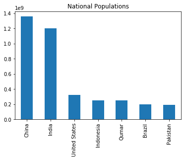

```python
populations.plot(kind = "bar", \
                 title="National Populations")
```

#### Horizontal bar chart

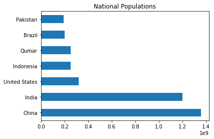

```python
populations.plot(kind = "barh", \
                 title="National Populations")
```

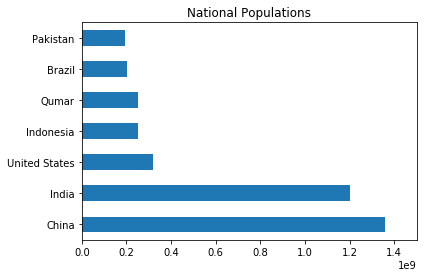

```python
populations.plot(kind = "barh", \
                 title="National Populations", \
                 xlim = (0, 1500000000))
```

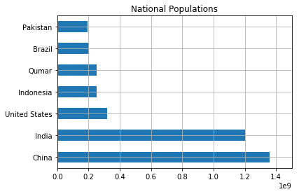

```python
populations.plot(kind = "barh", \
                 title="National Populations", \
                 xlim = (0, 1500000000), \
                 grid=True)
```

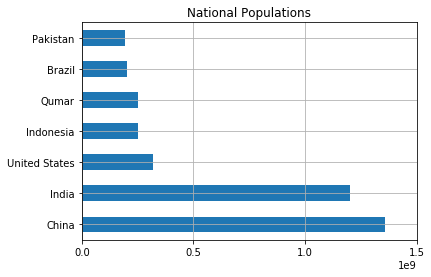

```python
populations.plot(kind = "barh", title="National Populations", \
                 xlim = (0, 1500000000), \
                 grid=True,
                 xticks=(0, 500000000, 1000000000, 1500000000))
```

We can easily change the colours of the bars in a bar plot using the *color* attribute.

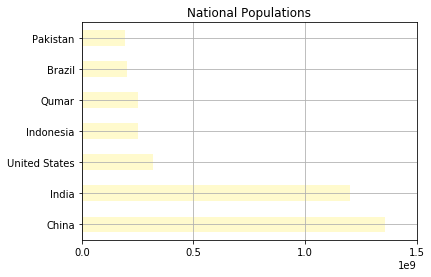

```python
populations.plot(kind = "barh", \
                 title="National Populations", \
                 xlim = (0, 1500000000), \
                 grid=True, \
                 xticks=(0, 500000000, 1000000000, 1500000000), \
                 color = ['lemonchiffon', '#00ff00', 'blue'])
```

Full list of named matplotlib colours is availabe [here](http://matplotlib.org/examples/color/named_colors.html)

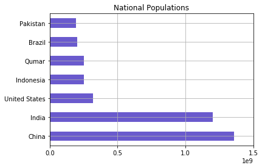

```python
populations.plot(kind = "barh", \
                 title="National Populations", \
                 xlim = (0, 1500000000), \
                 grid=True, xticks=(0, 500000000, 1000000000, 1500000000), \
                 color = 'slateblue')
```

Or we can give colours as RGB values in hex code

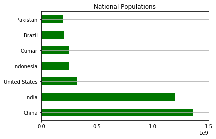

```python
populations.plot(kind = "barh", title="National Populations", xlim = (0, 1500000000), grid=True, xticks=(0, 500000000, 1000000000, 1500000000), color = '#007700')
```

If we have a categorical series we first need to generate a frequency table before plotting abar chart

```python
parties = ['FG', 'FF', 'IO', 'SF', 'Lab', 'AAA-PBP', 'SD', 'GP', 'RI']
votes = pd.Series(np.random.choice(parties, 100000, p=[0.25, 0.24, 0.18, 0.14, 0.066, 0.040, 0.035, 0.027, 0.022]))
print(votes)
```

```
0             FG
1             FF
2             FF
3             FF
4             SF
5             IO
6             GP
7             FF
8             FF
9             FG
10            IO
11            FG
12            FF
13            FG
14            FG
```

[output cut: 47 more lines]

```python
votes.plot(kind="bar")
```

[output not shown]

```python
vc = votes.value_counts()
vc
```

```
FG         25000
FF         23868
IO         17890
SF         14175
Lab         6748
AAA-PBP     3998
SD          3443
GP          2660
RI          2218
dtype: int64
```

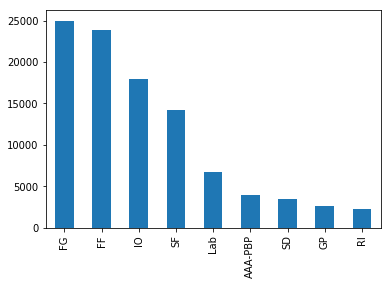

```python
vc.plot(kind = 'bar')
```

#### Pie chart

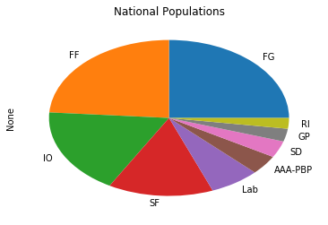

```python
vc.plot(kind = "pie", \
        title="National Populations")
```

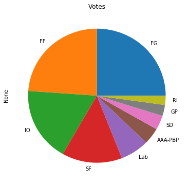

```python
vc.plot(kind = "pie", \
                 title="Votes", \
                figsize=(6,6))
```

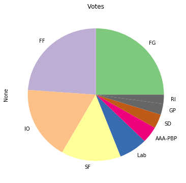

```python
vc.plot(kind = "pie", \
                 title="Votes", \
                 figsize=(6,6), \
                 colormap = "Accent")
```

#### Histograms

Generate some data for histograms

```python
mu = 165
sigma = 20
heights = pd.Series(np.random.normal(mu, sigma, 1000))
heights
```

```
0      160.963934
1      203.549719
2      164.375624
3      145.639564
4      196.660160
5      170.931819
6      164.335711
7      167.474836
8      191.581108
9      157.831316
10     131.284985
11     154.259100
12     168.056799
13     163.605443
14     145.223637
```

[output cut: 47 more lines]

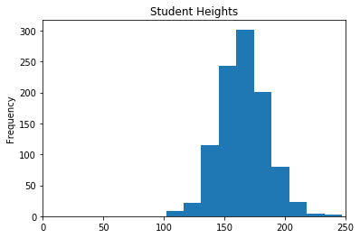

```python
heights.plot(kind="hist", \
             title = "Student Heights", \
             xlim = (0, 250))
```

#### Box plots

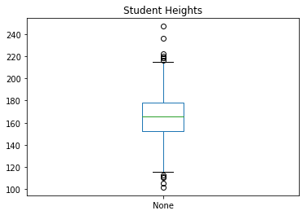

```python
heights.plot(kind="box", title = "Student Heights")
```

#### Density plots

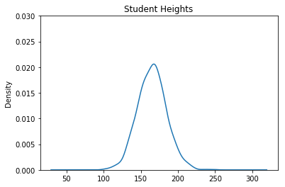

```python
heights.plot(kind="kde", title = "Student Heights", ylim = (0, 0.03))
```

#### Line plots

Generate some time series data for line and area plots.

```python
ts = pd.Series(np.random.randn(1000), index=pd.date_range('1/1/2015', periods=1000))
ts = ts.cumsum()
```

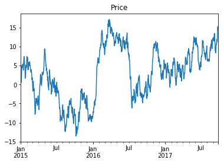

```python
ts.plot(kind = "line", title = "Price")
```

#### Area Plot

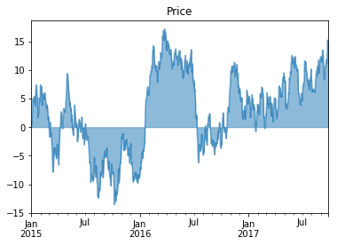

```python
ts.plot(kind = "area", title = "Price", stacked= False)
```

### Scatter Plots

Scatter plots are great for displaying relationships between variables.

Load a dataset so we can look at some scatter plots.

```python
PAYE_Fraud = pd.read_csv("PAYE_Fraud.csv")
PAYE_Fraud.head()
PAYE_Fraud.shape
```

```
(5200, 16)
```

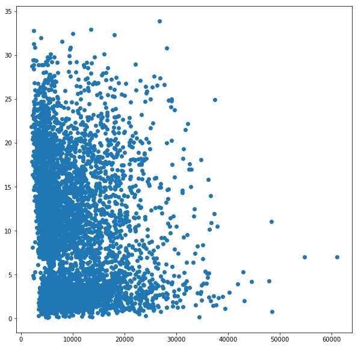

```python
plt.figure(figsize=(10, 10))
plt.scatter(PAYE_Fraud["TaxPaid"], \
            PAYE_Fraud["YearsInCurrentEmployment"])
```

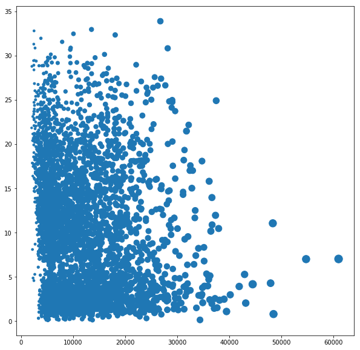

```python
plt.figure(figsize=(10, 10))
plt.scatter(PAYE_Fraud["TaxPaid"], \
            PAYE_Fraud["YearsInCurrentEmployment"], \
            s = PAYE_Fraud["TotalIncome"]/1000)
```

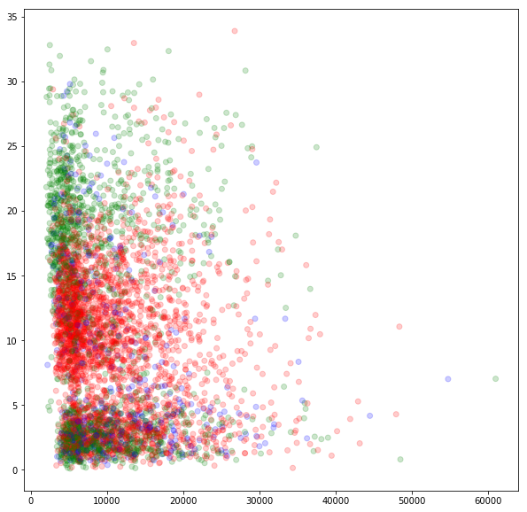

```python
plt.figure(figsize=(10, 10))
colMap = {"Employed":"Red", 'Self-Employed':"Green", "Casual":"Blue"}
plt.scatter(PAYE_Fraud["TaxPaid"], \
            PAYE_Fraud["YearsInCurrentEmployment"], \
            c = PAYE_Fraud["OccupationType"].map(colMap), \
            alpha=0.2)
```

A **scatter plot matrix** or **SPLOM** is a nice way to create a set of scatter plots for a collection of variables. **pandas** has a fucntion, **scatter_matrix** to draw scatter plot matrices.

```
array([[<matplotlib.axes._subplots.AxesSubplot object at 0x113ffd1d0>,
      dtype=object)
```

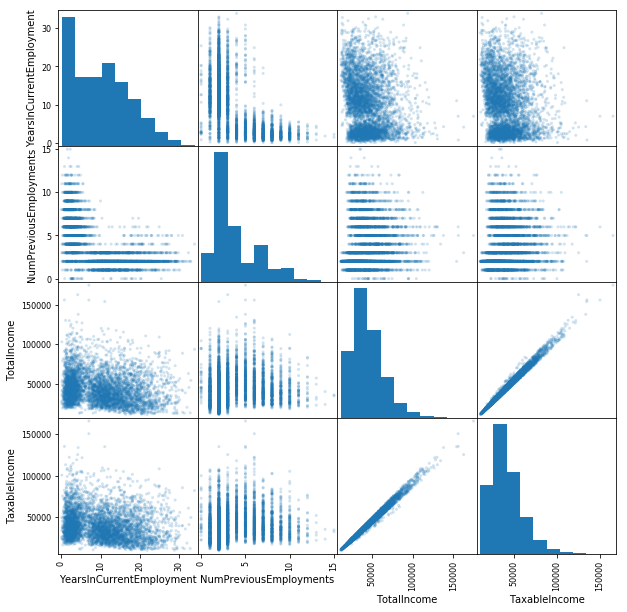

```python
from pandas.tools.plotting import scatter_matrix
scatter_matrix(PAYE_Fraud[["YearsInCurrentEmployment", "NumPreviousEmployments", "TotalIncome", "TaxableIncome"]], alpha=0.2, figsize=(10, 10), diagonal='hist')
```

A **hexbin** plot is an alternative to a simple scatter plot that solves a problem that arises when datasets are very large. We use the **seaborn** package to draw hexbin plots.

```python
import seaborn as sns
from scipy.stats import kendalltau # Used for performing a correlation test between varaibles in hexbin
sns.set(style="ticks") # Makes for nicer looking histograms
```

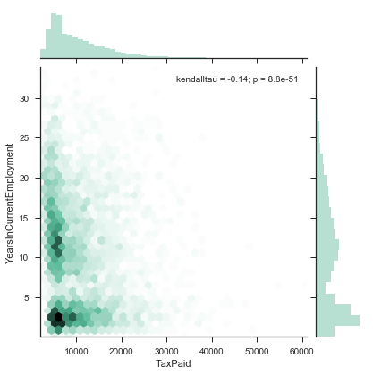

```python
sns.jointplot(PAYE_Fraud["TaxPaid"], PAYE_Fraud["YearsInCurrentEmployment"], kind="hex", stat_func=kendalltau, color="#4CB391")
```

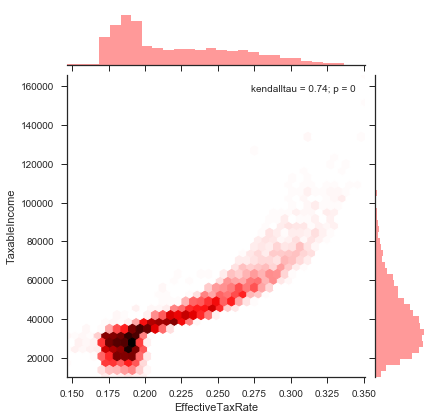

```python
sns.jointplot(PAYE_Fraud["EffectiveTaxRate"], PAYE_Fraud["TaxableIncome"], kind="hex", stat_func=kendalltau, color="red")
```

### matplotlib Styles

We can change styles in matplotlib easily

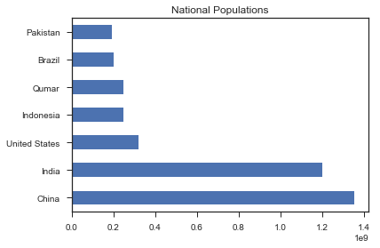

```python
populations.plot(kind = "barh", title="National Populations")
```

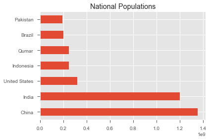

```python
matplotlib.style.use('ggplot')
populations.plot(kind = "barh", title="National Populations")
```

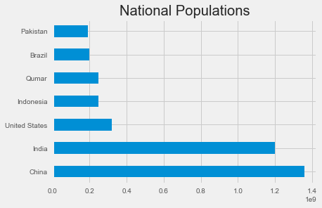

```python
matplotlib.style.use('fivethirtyeight')
populations.plot(kind = "barh", title="National Populations")
```

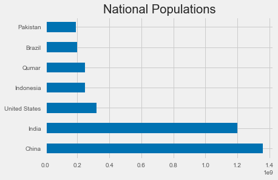

```python
matplotlib.style.use('seaborn-colorblind')
populations.plot(kind = "barh", title="National Populations")
```

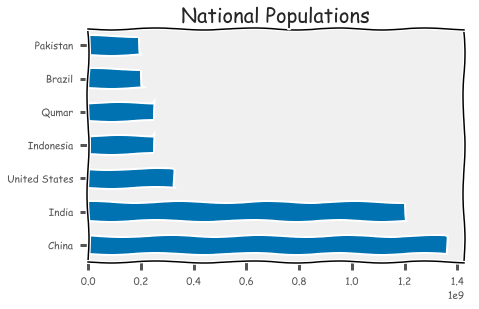

```python
plt.xkcd()
populations.plot(kind = "barh", title="National Populations")
```

### Saving Plots

We can easily save plots we generate in our notebooks.

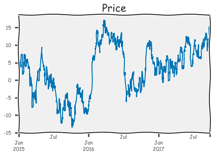

```python
ts.plot(kind = "line", title = "Price")
plt.savefig('lineplot.pdf')
```

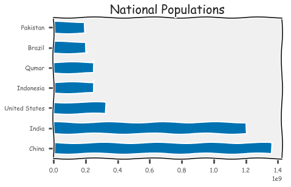

```python
populations.plot(kind = "barh", title="National Populations")
plt.savefig('barplot.pdf')
```